# Final Project

Cynthia Petrossian

5/9/2022

# Load Libraries

```r
library(tidyverse)
library(here)
library(janitor)
library(ggpubr)
library(gganimate)
library(gifski)
library(prettydoc)
library(magick)
```

# Introduction

The integrity of organs and bodily tissues relies on adult stem cells (ASCs). ASCs divide to replace any cells lost to damage, disease, or regular turnover. There are many factors that control the differentiation and division of ASCs, notably master regulators (MRs) and their downstream targets.

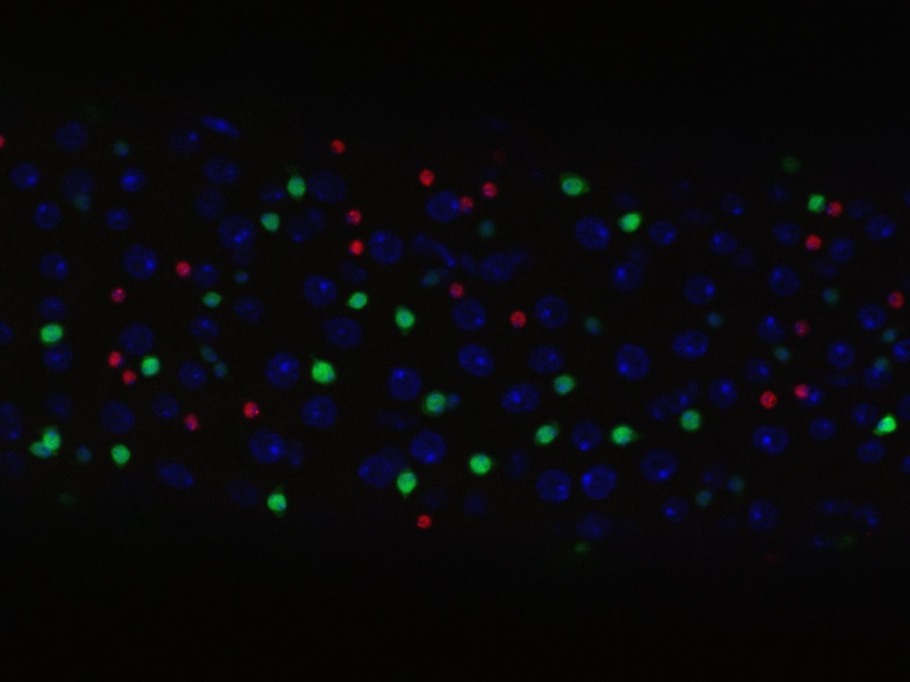

```r
image_read(here("Final_Project", "Images", "iscs.jpg"))  #Read in ISC image
```

While the effects of manipulating MRs on ASCs have been well characterized, and many of their potential downstream targets identified, validation of these targets and a mechanistic explanation of how they function within ASCs is still largely lacking.

To explore this, we use the model system *Drosophila melanogaster*, the fruit fly. We specifically study intestinal stem cells (ISCs) in the posterior midgut region of the fly.

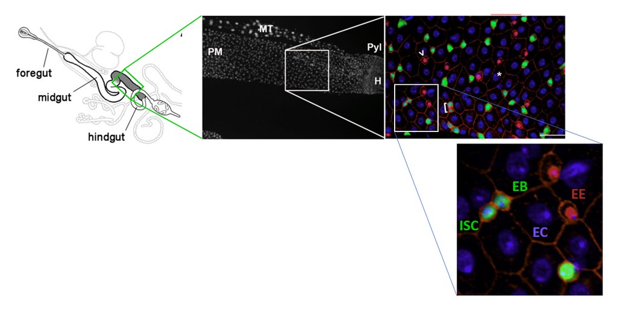

```r
image_read(here("Final_Project", "Images", "modelsystem.png"))  #Read in model system image
```

We will focus on two well-known MRs of ISCs in *Drosophila*, Escargot (Esg) and STAT. While previous work in our lab has validated several targets regulated by Esg, STAT, or both, the role of these targets themselves in ISC regulation has not been investigated.

We will attempt to elucidate the roles of these targets by manipulating their genetic expression and observing the effects of this manipulation on ISC morphology.

For this project, we will focus on the downstream genetic target Indy. We genetically manipulated the expression of Indy by overexpressing it in *Drosophila* ISCs and visualized the intestinal cells through immunofluorescence microscopy.

We used Cell Profiler, a “free, open-source software designed to … quantitatively measure phenotypes from thousands of images automatically” to generate numerical data of the phenotypes observed. This data was used for the following plots.

# Indy Overexpression Phenotypes

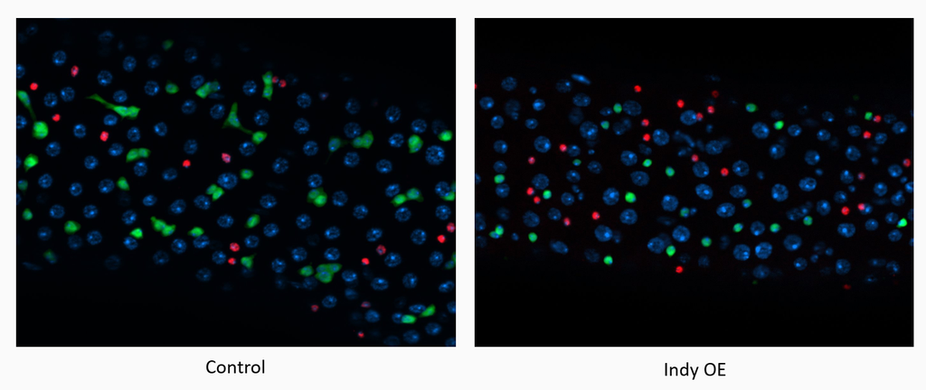

```r
image_read(here("Final_Project", "Images", "indyoe.png"))  #Read in indyoe image
```

We visually saw an increase in the number of red enteroendocrine (EE) cells relative to the number of green progenitor cells in Indy OE.

I will read in the data of EE and progenitor cell counts and plot it.

# Increase in Enteroendrocrine Counts

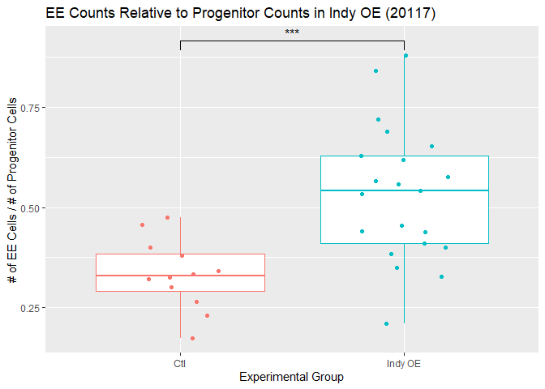

```r
cells <- read_csv(here("Final_Project", "Data", "EE_Progenitor_Counts", "ee_progenitor_counts.csv")) #read in data
view(cells) #view data

cells %>%
  ggplot(aes(x = group, #create ggplot, set x axis as experimental group
             y = ratio, #set y axis as ratio
             color = group))+ #set color as group
  geom_boxplot()+ #geom boxplot
  geom_point(position = position_jitterdodge())+ #add jittered points
  labs(title = "EE Counts Relative to Progenitor Counts in Indy OE (20117)", #add title
       y = "# of EE Cells / # of Progenitor Cells", #add y axis label
       x = "Experimental Group")+ #add x axis label
  guides(color = FALSE)+#remove legend
   geom_signif(comparisons = list(c("Ctl", "Indy OE")), #determine significance
              map_signif_level=TRUE, #show significance on plot
              color = "black")  #change bracket color to black
```

# Indy Overexpression Phenotypes

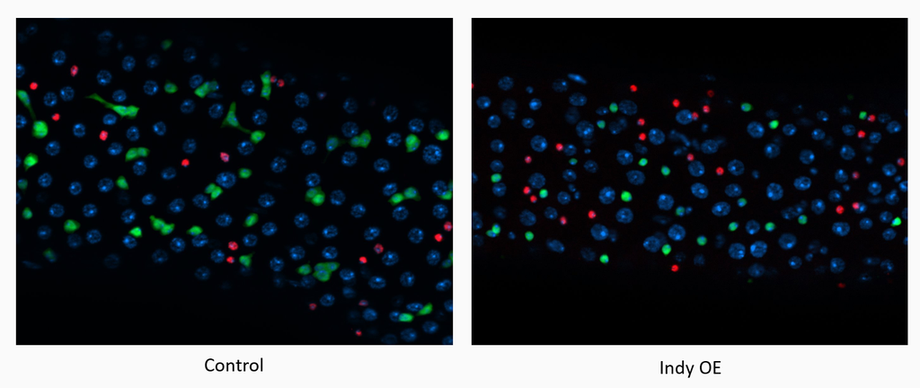

```r
image_read(here("Final_Project", "Images", "indyoe.png"))  #Read in indyoe image
```

We also noticed that it appeared as if blue enterocytes (ECs) were more spread out from each other in the Indy OE compared to control. We used CellProfiler to quantify the distances between ECs in control and Indy OE guts. We automatically detected EC cells from microscopy images using CellProfiler, and then extracted measurements of the distances between each EC and its first and second closest neighboring EC.

First I will read in the data and wrangle it into an appropriate structure for plotting.

# 20117 Data Wrangling

```r
indy1ctl <- read_csv(here("Final_Project", "Data", "20117",  "DAPIcells_Filtered_DAPI_nuclei_ctl.csv")) #read in data
indy1exp <- read_csv(here("Final_Project", "Data", "20117",  "DAPIcells_Filtered_DAPI_nuclei_exp.csv")) #read in data

indy1ctl <- indy1ctl %>%
  clean_names() #clean column names with janitor package
indy1ctl #view indy1ctl
```

```
## # A tibble: 6,583 x 7
##    image_number object_number metadata_file_location metadata_group metadata_gut
##           <dbl>         <dbl> <chr>                  <chr>                 <dbl>
##  1            1             1 file:///C:/Users/cynt~ Ctl                      10
##  2            1             2 file:///C:/Users/cynt~ Ctl                      10
##  3            1             3 file:///C:/Users/cynt~ Ctl                      10
##  4            1             4 file:///C:/Users/cynt~ Ctl                      10
##  5            1             5 file:///C:/Users/cynt~ Ctl                      10
##  6            1             6 file:///C:/Users/cynt~ Ctl                      10
##  7            1             7 file:///C:/Users/cynt~ Ctl                      10
##  8            1             8 file:///C:/Users/cynt~ Ctl                      10
##  9            1             9 file:///C:/Users/cynt~ Ctl                      10
## 10            1            10 file:///C:/Users/cynt~ Ctl                      10
## # ... with 6,573 more rows, and 2 more variables:
## #   neighbors_first_closest_distance_expanded <dbl>,
## #   neighbors_second_closest_distance_expanded <dbl>
```

```r
indy1exp <- indy1exp %>%
  clean_names() #clean column names with janitor package
indy1exp #view indy1exp
```

```
## # A tibble: 6,607 x 7
##    image_number object_number metadata_file_location metadata_group metadata_gut
##           <dbl>         <dbl> <chr>                  <chr>                 <dbl>
##  1            1             1 file:///C:/Users/cynt~ Indy OE                  13
##  2            1             2 file:///C:/Users/cynt~ Indy OE                  13
##  3            1             3 file:///C:/Users/cynt~ Indy OE                  13
##  4            1             4 file:///C:/Users/cynt~ Indy OE                  13
##  5            1             5 file:///C:/Users/cynt~ Indy OE                  13
##  6            1             6 file:///C:/Users/cynt~ Indy OE                  13
##  7            1             7 file:///C:/Users/cynt~ Indy OE                  13
##  8            1             8 file:///C:/Users/cynt~ Indy OE                  13
##  9            1             9 file:///C:/Users/cynt~ Indy OE                  13
## 10            1            10 file:///C:/Users/cynt~ Indy OE                  13
## # ... with 6,597 more rows, and 2 more variables:
## #   neighbors_first_closest_distance_expanded <dbl>,
## #   neighbors_second_closest_distance_expanded <dbl>
```

```r
indy1ctl <- mutate(.data = indy1ctl,
                    metadatagroup = "Ctl",
                    line = "20117") #add new column for metadatagroup to indy1ctl dataframe - have it say "Ctl"

indy1exp <- mutate(.data = indy1exp,
                    metadatagroup = "Indy OE",
                    line = "20117") #add new column for metadatagroup to indy1exp  - have it say "Indy OE"


combinedindy1 <- bind_rows(indy1ctl, indy1exp) #stack the two dataframes on top of each other
combinedindy1 #view combined dataframes
```

```
## # A tibble: 13,190 x 9
##    image_number object_number metadata_file_location metadata_group metadata_gut
##           <dbl>         <dbl> <chr>                  <chr>                 <dbl>
##  1            1             1 file:///C:/Users/cynt~ Ctl                      10
##  2            1             2 file:///C:/Users/cynt~ Ctl                      10
##  3            1             3 file:///C:/Users/cynt~ Ctl                      10
##  4            1             4 file:///C:/Users/cynt~ Ctl                      10
##  5            1             5 file:///C:/Users/cynt~ Ctl                      10
##  6            1             6 file:///C:/Users/cynt~ Ctl                      10
##  7            1             7 file:///C:/Users/cynt~ Ctl                      10
##  8            1             8 file:///C:/Users/cynt~ Ctl                      10
##  9            1             9 file:///C:/Users/cynt~ Ctl                      10
## 10            1            10 file:///C:/Users/cynt~ Ctl                      10
## # ... with 13,180 more rows, and 4 more variables:
## #   neighbors_first_closest_distance_expanded <dbl>,
## #   neighbors_second_closest_distance_expanded <dbl>, metadatagroup <chr>,
## #   line <chr>
```

```r
means_combinedindy1 <- combinedindy1 %>% #create new df
  group_by(metadatagroup, metadata_gut, line) %>% #group by experimental group and gut number
  summarise(first_distance_mean = mean(neighbors_first_closest_distance_expanded), #get means for first distance
            second_distance_mean = mean(neighbors_second_closest_distance_expanded)) %>% #get means for second distance
  mutate(microns_first = first_distance_mean/6.20, #add new column called "microns_first" - convert distances from pixels to microns by dividing by 6.2
         microns_second = second_distance_mean/6.20) #add new column called "microns_second" - convert distances from pixels to microns by dividing by 6.2
view(means_combinedindy1) #viewnew dataframe

rfindy1 <- means_combinedindy1 %>% #create new dataframe
  rowwise() #use rowwise to allow for computing of dataframe on row by row basis
rfindy1 #view dataframe
```

```
## # A tibble: 58 x 7
## # Rowwise:  metadatagroup, metadata_gut
##    metadatagroup metadata_gut line  first_distance_mean second_distance_mean
##    <chr>                <dbl> <chr>               <dbl>                <dbl>
##  1 Ctl                      1 20117                57.3                 72.5
##  2 Ctl                      2 20117                60.4                 77.6
##  3 Ctl                      4 20117                60.8                 73.6
##  4 Ctl                      5 20117                54.7                 69.0
##  5 Ctl                      6 20117                51.1                 64.1
##  6 Ctl                      7 20117                50.8                 61.6
##  7 Ctl                      8 20117                55.3                 68.8
##  8 Ctl                     10 20117                62.1                 73.8
##  9 Ctl                     11 20117                63.5                 77.4
## 10 Ctl                     12 20117                66.8                 80.7
## # ... with 48 more rows, and 2 more variables: microns_first <dbl>,
## #   microns_second <dbl>
```

# 21412 Data Wrangling

```r
indy2ctl <- read_csv(here("Final_Project", "Data", "21412", "DAPIcells_Filtered_DAPI_nuclei_ctl.csv")) #read in data
indy2exp <- read_csv(here("Final_Project", "Data", "21412",  "DAPIcells_Filtered_DAPI_nuclei_exp.csv")) #read in data

indy2ctl <- indy2ctl %>%
  clean_names() #clean names using janitor package
indy2ctl #view df
```

```
## # A tibble: 3,497 x 7
##    image_number object_number metadata_file_location metadata_group metadata_gut
##           <dbl>         <dbl> <chr>                  <chr>                 <dbl>
##  1            1             1 file:///C:/Users/cynt~ Ctl                      12
##  2            1             2 file:///C:/Users/cynt~ Ctl                      12
##  3            1             3 file:///C:/Users/cynt~ Ctl                      12
##  4            1             4 file:///C:/Users/cynt~ Ctl                      12
##  5            1             5 file:///C:/Users/cynt~ Ctl                      12
##  6            1             6 file:///C:/Users/cynt~ Ctl                      12
##  7            1             7 file:///C:/Users/cynt~ Ctl                      12
##  8            1             8 file:///C:/Users/cynt~ Ctl                      12
##  9            1             9 file:///C:/Users/cynt~ Ctl                      12
## 10            1            10 file:///C:/Users/cynt~ Ctl                      12
## # ... with 3,487 more rows, and 2 more variables:
## #   neighbors_first_closest_distance_expanded <dbl>,
## #   neighbors_second_closest_distance_expanded <dbl>
```

```r
indy2exp <- indy2exp %>%
  clean_names() #clean names using janitor package
indy2exp #view df
```

```
## # A tibble: 6,669 x 7
##    image_number object_number metadata_file_location metadata_group metadata_gut
##           <dbl>         <dbl> <chr>                  <chr>                 <dbl>
##  1            1             1 file:///C:/Users/cynt~ Indy OE                  10
##  2            1             2 file:///C:/Users/cynt~ Indy OE                  10
##  3            1             3 file:///C:/Users/cynt~ Indy OE                  10
##  4            1             4 file:///C:/Users/cynt~ Indy OE                  10
##  5            1             5 file:///C:/Users/cynt~ Indy OE                  10
##  6            1             6 file:///C:/Users/cynt~ Indy OE                  10
##  7            1             7 file:///C:/Users/cynt~ Indy OE                  10
##  8            1             8 file:///C:/Users/cynt~ Indy OE                  10
##  9            1             9 file:///C:/Users/cynt~ Indy OE                  10
## 10            1            10 file:///C:/Users/cynt~ Indy OE                  10
## # ... with 6,659 more rows, and 2 more variables:
## #   neighbors_first_closest_distance_expanded <dbl>,
## #   neighbors_second_closest_distance_expanded <dbl>
```

```r
indy2ctl <- mutate(.data = indy2ctl,
                    metadatagroup = "Ctl",
                    line = "21412") #add new column to df called "metadatagrop" and set as "Ctl"

indy2ctl
```

```
## # A tibble: 3,497 x 9
##    image_number object_number metadata_file_location metadata_group metadata_gut
##           <dbl>         <dbl> <chr>                  <chr>                 <dbl>
##  1            1             1 file:///C:/Users/cynt~ Ctl                      12
##  2            1             2 file:///C:/Users/cynt~ Ctl                      12
##  3            1             3 file:///C:/Users/cynt~ Ctl                      12
##  4            1             4 file:///C:/Users/cynt~ Ctl                      12
##  5            1             5 file:///C:/Users/cynt~ Ctl                      12
##  6            1             6 file:///C:/Users/cynt~ Ctl                      12
##  7            1             7 file:///C:/Users/cynt~ Ctl                      12
##  8            1             8 file:///C:/Users/cynt~ Ctl                      12
##  9            1             9 file:///C:/Users/cynt~ Ctl                      12
## 10            1            10 file:///C:/Users/cynt~ Ctl                      12
## # ... with 3,487 more rows, and 4 more variables:
## #   neighbors_first_closest_distance_expanded <dbl>,
## #   neighbors_second_closest_distance_expanded <dbl>, metadatagroup <chr>,
## #   line <chr>
```

```r
indy2exp <- mutate(.data = indy2exp,
                    metadatagroup = "Indy OE",
                    line = "21412") #add new column to df called "metadatagrop" and set as "Indy OE"

combinedindy2 <- bind_rows(indy2ctl, indy2exp) #stack dfs on top of each other
view(combinedindy2) #view new df

means_combinedindy2 <- combinedindy2 %>% #create new df
  group_by(metadatagroup, metadata_gut, line) %>% #group by metaadatagroup and gut number
  summarise(first_distance_mean = mean(neighbors_first_closest_distance_expanded), #get first distance means
            second_distance_mean = mean(neighbors_second_closest_distance_expanded)) %>% #get second distance means
  mutate(microns_first = first_distance_mean/6.20, #add new column called "microns_first" to convert pixels to microns by dividing by 6.2
         microns_second = second_distance_mean/6.20) #add new column called "microns_second" to convert pixels to microns by dividing by 6.2
view(means_combinedindy2) #view df

rfindy2 <- means_combinedindy2 %>% #create new df
  rowwise() #use rowwise to allow for computing dataframe on row by row basis
rfindy2 #view df
```

```
## # A tibble: 52 x 7
## # Rowwise:  metadatagroup, metadata_gut
##    metadatagroup metadata_gut line  first_distance_mean second_distance_mean
##    <chr>                <dbl> <chr>               <dbl>                <dbl>
##  1 Ctl                      2 21412                60.9                 77.9
##  2 Ctl                      4 21412                66.0                 83.8
##  3 Ctl                      6 21412                68.7                 86.3
##  4 Ctl                      8 21412                69.2                 86.2
##  5 Ctl                     12 21412                67.3                 83.8
##  6 Ctl                     13 21412                84.6                109.
##  7 Ctl                     15 21412                77.3                 93.6
##  8 Ctl                     17 21412                81.1                101.
##  9 Ctl                     18 21412                71.0                 91.4
## 10 Ctl                     19 21412                79.7                 94.2
## # ... with 42 more rows, and 2 more variables: microns_first <dbl>,
## #   microns_second <dbl>
```

I will them combine the two dataframes to use in one type of plot.

# Data Wrangling of Both 20117 & 21412

```r
combinedindy <- bind_rows(means_combinedindy1, means_combinedindy2) #stack dfs on top of each other
view(combinedindy) #view new df

rfindy <- combinedindy %>%
  rowwise() #use rowwise to allow for computing dataframe on row by row basis
rfindy #view df
```

```
## # A tibble: 110 x 7
## # Rowwise:  metadatagroup, metadata_gut
##    metadatagroup metadata_gut line  first_distance_mean second_distance_mean
##    <chr>                <dbl> <chr>               <dbl>                <dbl>
##  1 Ctl                      1 20117                57.3                 72.5
##  2 Ctl                      2 20117                60.4                 77.6
##  3 Ctl                      4 20117                60.8                 73.6
##  4 Ctl                      5 20117                54.7                 69.0
##  5 Ctl                      6 20117                51.1                 64.1
##  6 Ctl                      7 20117                50.8                 61.6
##  7 Ctl                      8 20117                55.3                 68.8
##  8 Ctl                     10 20117                62.1                 73.8
##  9 Ctl                     11 20117                63.5                 77.4
## 10 Ctl                     12 20117                66.8                 80.7
## # ... with 100 more rows, and 2 more variables: microns_first <dbl>,
## #   microns_second <dbl>
```

I will now begin plotting.

# First Distance Means Plot (Animated)

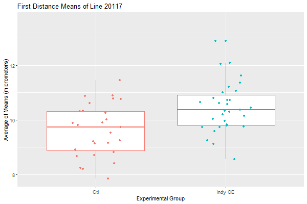

```r
first <- combinedindy %>% #create ggplot from this data
  ggplot(aes(x = metadatagroup, #set x axis as metadatagroup
             y = microns_first, #set y axis as microns
             color = metadatagroup))+ #set color as metadatagroup
  geom_boxplot()+ #geom is boxplot
  geom_point(position = position_jitterdodge())+
  labs(x = "Experimental Group", #add x axis label
       y = "Average of Means (micrometers)")+ #add y axis label
  guides(color = FALSE)+ #remove legend
transition_states(line, #the thing you are animating by
                    transition_length = 2, #relative length of transition (length between transitions)
                    state_length = 1)+ #The length between end and beginning of gif
  ease_aes("sine-in-out")+ #add easing of aesthetics as sine in out
  ggtitle("First Distance Means of Line {closest_state}") #title changes according to line being animated

  animate(first, height=400, width=600, renderer=gifski_renderer()) #render animation with gifski package
```

```r
  anim_save("combinedmeans.gif", first) #save animation
```

# 20117 First Distance Means Plot

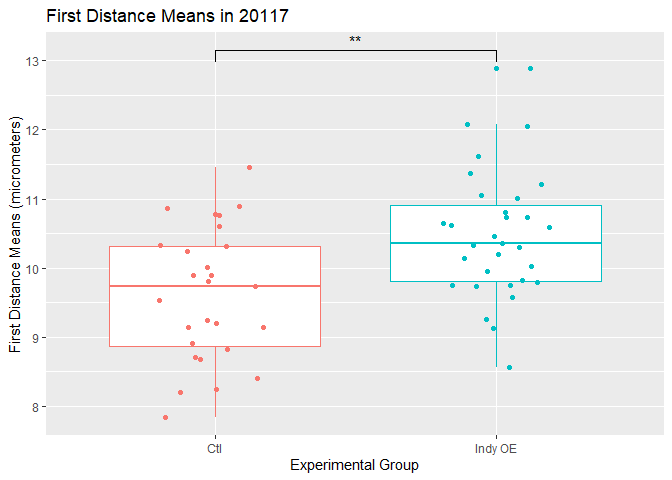

```r
means_combinedindy1 %>% #create ggplot from this data
  ggplot(aes(x = metadatagroup, #set x axis as metadatagroup
             y = microns_first, #set y axis as microns
             color = metadatagroup))+ #set color to metedatagroup
  geom_boxplot()+ #geom is boxplot
  geom_point(position = position_jitterdodge())+
  labs(title = "First Distance Means in 20117", #add title
       y = "First Distance Means (micrometers)", #add y axis label
       x = "Experimental Group")+ #add x axis label
  guides(color = FALSE)+ #remove legend
  geom_signif(comparisons = list(c("Ctl", "Indy OE")), #get significance
              map_signif_level=TRUE, #add significance to plot
              color = "black")  #change bracket color to black
```

# 21412 First Distance Means Plot

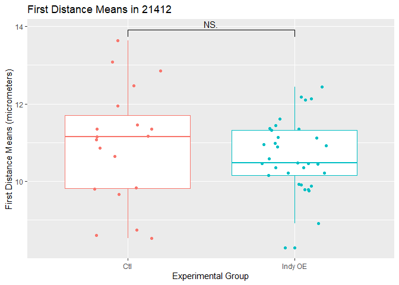

```r
means_combinedindy2 %>% #create ggplot from this data
  ggplot(aes(x = metadatagroup, #set x axis as metadatagroup
             y = microns_first, #set y axis as microns
             color = metadatagroup))+ #set color as metadatagroup
  geom_boxplot()+ #geom is boxplot
  geom_point(position = position_jitterdodge())+ #add jittered points
  labs(title = "First Distance Means in 21412", #add title
       y = "First Distance Means (micrometers)", #add y axis label
       x = "Experimental Group")+ #add x axis label
  guides(color = FALSE)+ #remove legend
  geom_signif(comparisons = list(c("Ctl", "Indy OE")), #get significance
              map_signif_level=TRUE, #add significance to plot
              color = "black")  #change bracket color to black
```